# SARFRAZ_HW2_310

Hussain Sarfraz

1/24/2022

# Question 1

## Part A

> 1. p(24 < X < 30) = ?

**Answer: 0.3141458**

To solve this question I used the `pnorm()` function to find the area under the graph that is to the left of point 30 on the X-axis. I then found the area under the graph that is to the left of point 24 on the X-axis. Using this method I was able to find the area under the graph that was in between point **30 and 24** on the X-axis.

```r
pnorm(30,26,sqrt(54),lower.tail = T)-pnorm(24,26,sqrt(54),lower.tail = T)
```

```
## [1] 0.3141458
```

> 2. Solve for c such that p(X < 45) = p(Z < c), where Z ∼ N(0, 1)

**Answer: c = 2.585573**

To solve this question I used the `pnorm()` function to find the area under the normal random variable curve. Once I got the area under the curve (aka probability) I could solve for **c**.

To solve for **c** I used the `qnorm()` function and imputed the previous `pnorm()` function into the first value just so I can make sure I include all the numbers in my calculations.

```r
#first find area under the normal random variable curve
#pnorm(45,26,sqrt(54),lower.tail = T) #output: 0.9951391

#second, solve for c
#qnorm(0.9951391,0,sqrt(1),lower.tail = T)
qnorm(pnorm(45,26,sqrt(54),lower.tail = T),0,sqrt(1),lower.tail = T)
```

```
## [1] 2.585573
```

> 3. Find lb and ub on the symmetric CI such p(lb < X < ub) = 0.90

**Answer: lb = 13.91284 and ub = 38.08716**

To solve for **lb and ub** I used the `qnorm()` function. I made sure that I imputed the probability (or area under the curve) of **0.05 and 0.95** in the `qnorm()` function because in order for me to figure out the intervals that cover **90%** of the area under the graph I had to make sure the sides of the graph added up to **0.10**

```r
#lb
qnorm(0.05,26,sqrt(54),lower.tail = T)
```

```
## [1] 13.91284
```

```r
#ub
qnorm(0.95,26,sqrt(54),lower.tail = T)
```

```
## [1] 38.08716
```

## Part B

> 1. p(40 < Y < 50) = ?

**Answer: 0.6619928**

The logic to this question is similar to the one used in **Q.A.i**

```r
pnorm(50,43,sqrt(23),lower.tail = T)-pnorm(40,43,sqrt(23),lower.tail = T)
```

```
## [1] 0.6619928
```

> 2. Solve for c such that p(Y < 35) = p(Z < c), where Z ∼ N(0, 1)

**Answer: -1.668115**

The logic to this question is similar to the one used in **Q.A.ii**

```r
#first find area under the normal random variable curve
#pnorm(35,43,sqrt(23),lower.tail = T)

#second, solve for c
#qnorm(0.04764642,0,sqrt(1),lower.tail = T)
qnorm(pnorm(35,43,sqrt(23),lower.tail = T),0,sqrt(1),lower.tail = T)
```

```
## [1] -1.668115
```

> 3. Find the lb and ub on the symmetric CI such p(lb < Y < ub) = 0.99

**Answer: lb = 30.64676 and ub = 55.35324**

The logic to this question is similar to the one used in **Q.A.iii**

- One thing that I would highlight here is that the reason I used the probabilities **0.005** and **0.995** in the `qnorm()` function is to find the X-axis values that make up **99%** of the probabilities in the curve. This means that the side areas in the graph need to have a probability/area of **0.005** since **0.005+0.005 = 0.01**

```r
#lb
qnorm(0.005,43,sqrt(23),lower.tail = T)
```

```
## [1] 30.64676
```

```r
#ub
qnorm(0.995,43,sqrt(23),lower.tail = T)
```

```
## [1] 55.35324
```

# Question 2

## Part A

**Answer: 0.278044**

For this question I used the code in the `YahtzeeFirstRoll.R` file. The only changes I made to this code is that I changed the number of dice to be four since the question asks to: **Approximate probability of the “maxnumber” random variable equaling one when rolling four dice**

To calculate the probability I used the `table()` function to see how many times each number repeated. I then got the total amount of ones and divided it by the sum of the table (aka the total die rolls). I also used the `prop.table()` function to double check my answer.

```r
# How many dice
numdice = 4
# How many simulations
numsims = 1000000
# Initializes a vector that contains the outcome of each simulation
maxnumber <- matrix(NA, nrow = numsims, ncol = 1)
# Sets the seed
set.seed(12221979)

for (s in 1:numsims) {

  # Draws uniform r.v.
  uniform <- runif(n = numdice, min = 0, max = 1)
  # Initializes a vector
  dice <- matrix(-9, nrow = numdice, ncol = 1)
  # Transforms uniform r.v. into dice rolls
  # Applies inverse sampling
  dice[uniform >= 0 & uniform <= (1/6)] <- 1
  dice[uniform > (1/6) & uniform <= (2/6)] <- 2
  dice[uniform > (2/6) & uniform <= (3/6)] <- 3
  dice[uniform > (3/6) & uniform <= (4/6)] <- 4
  dice[uniform > (4/6) & uniform <= (5/6)] <- 5
  dice[uniform > (5/6) & uniform <= (6/6)] <- 6

  # Finds the mode of dice and stores in maxnum
  uniqv <- unique(dice)
  maxnum <- uniqv[which.max(tabulate(match(dice, uniqv)))]

  # Stores how many dice equal the mode
  maxnumber[s] <- sum(dice == maxnum)
}

#converting vector to dataframe
maxnumberdf <- as.data.frame(maxnumber)

#creating table to see how many times each value appears
#table(maxnumberdf)

#probability of one occuring with 4 dice
table(maxnumberdf)[0:1]/sum(table(maxnumberdf))
```

```
##        1
## 0.278044
```

```r
#using prop.table() to check my answer
prop.table(table(maxnumberdf))
```

```
## maxnumberdf
##        1        2        3        4
## 0.278044 0.624898 0.092465 0.004593
```

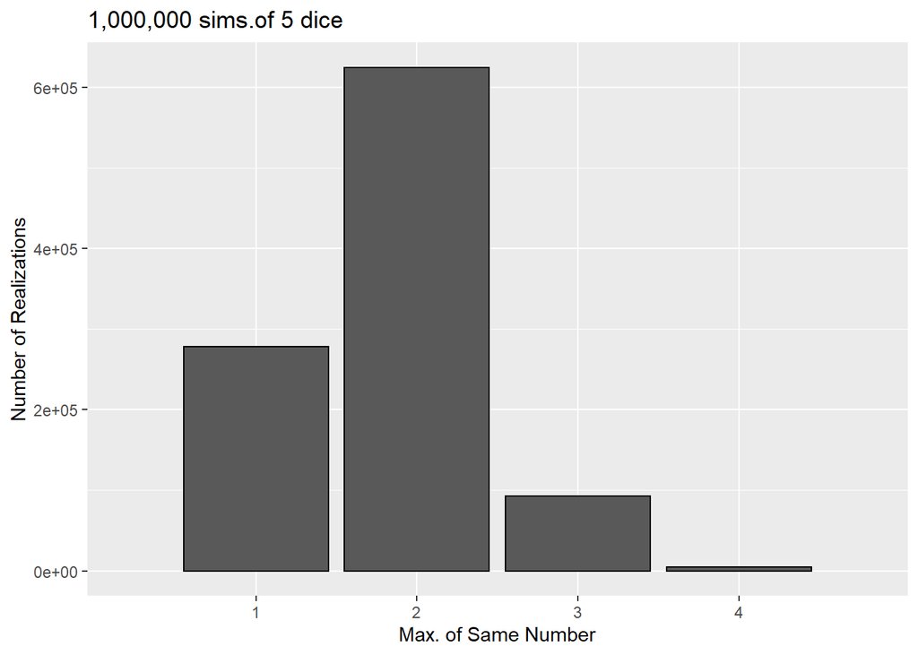

```r
# Plots histogram of the max number from each simulation
p <- ggplot(data=maxnumberdf, aes(x=V1)) +
  geom_bar( color="black") +
  scale_x_discrete(limits=c(1:numdice)) +
  labs(title="1,000,000 sims.of 5 dice",
       x="Max. of Same Number",
       y = "Number of Realizations")
p
```

## Part B

**Answer:0.366321**

My code for this question is the same as **Q 2.A** The only changes I made to this code is that I changed the number of dice to be **six** since the question asks to: **Approximate probability of the “maxnumber” random variable equaling three or more when we roll six dice**

To calculate the probability I used the `table()` and `sum()` function to see how many times each number equaling three or more repeated. I then got the total amount of equaling three or more occurances and divided it by the sum of the table (aka the total die rolls). I also used the `prop.table()` function to double check my answer.

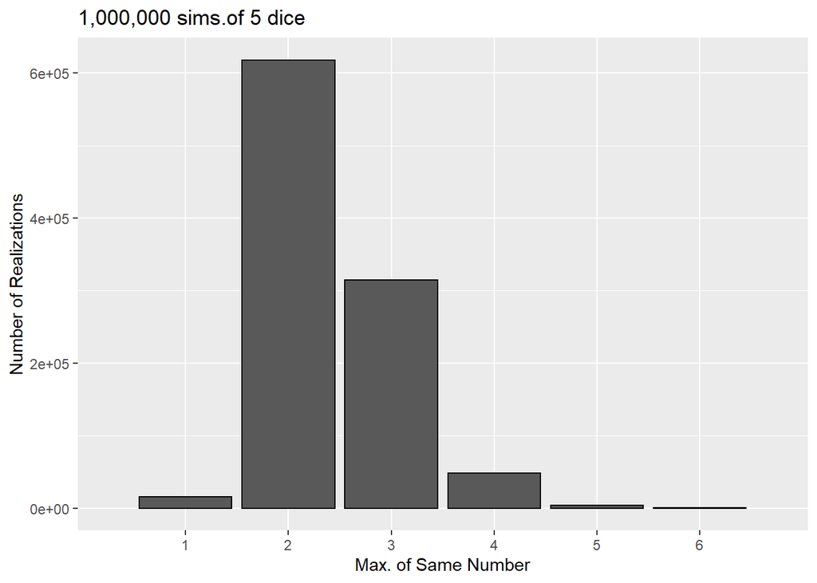

```r
# How many dice
numdice = 6
# How many simulations
numsims = 1000000
# Initializes a vector that contains the outcome of each simulation
maxnumber <- matrix(NA, nrow = numsims, ncol = 1)
# Sets the seed
set.seed(12221979)

for (s in 1:numsims) {

  # Draws uniform r.v.
  uniform <- runif(n = numdice, min = 0, max = 1)
  # Initializes a vector
  dice <- matrix(-9, nrow = numdice, ncol = 1)
  # Transforms uniform r.v. into dice rolls
  # Applies inverse sampling
  dice[uniform >= 0 & uniform <= (1/6)] <- 1
  dice[uniform > (1/6) & uniform <= (2/6)] <- 2
  dice[uniform > (2/6) & uniform <= (3/6)] <- 3
  dice[uniform > (3/6) & uniform <= (4/6)] <- 4
  dice[uniform > (4/6) & uniform <= (5/6)] <- 5
  dice[uniform > (5/6) & uniform <= (6/6)] <- 6

  # Finds the mode of dice and stores in maxnum
  uniqv <- unique(dice)
  maxnum <- uniqv[which.max(tabulate(match(dice, uniqv)))]

  # Stores how many dice equal the mode
  maxnumber[s] <- sum(dice == maxnum)
}

# Plots histogram of the max number from each simulation
maxnumberdf <- as.data.frame(maxnumber)
p <- ggplot(data=maxnumberdf, aes(x=V1)) +
  geom_bar( color="black") +
  scale_x_discrete(limits=c(1:numdice)) +
  labs(title="1,000,000 sims.of 5 dice",
       x="Max. of Same Number",
       y = "Number of Realizations")
p
```

```r
#sum(table(maxnumberdf)[3:6])
#probability of 3 or more occuring with 6 dice
sum(table(maxnumberdf)[3:6])/sum(table(maxnumberdf))
```

```
## [1] 0.366321
```

```r
#checking answer
sum(prop.table(table(maxnumberdf))[3:6])
```

```
## [1] 0.366321
```

## Part C

**Answer: 0.030573**

For this question I set the dice number to be **five** since the question states: **Approximate the probability of rolling a large straight with 5 dice**. I then created a vector called **rollsum** which basically stored all the sums of the die roll.

I then used the `mean()` function at the end to filter out the **rollsum** values that equal **15 or 20** because to get a straight the total of your dice will add up to those values. I also made sure that these values had a **maxnumber** of one to ensure that the dice were not repeated.

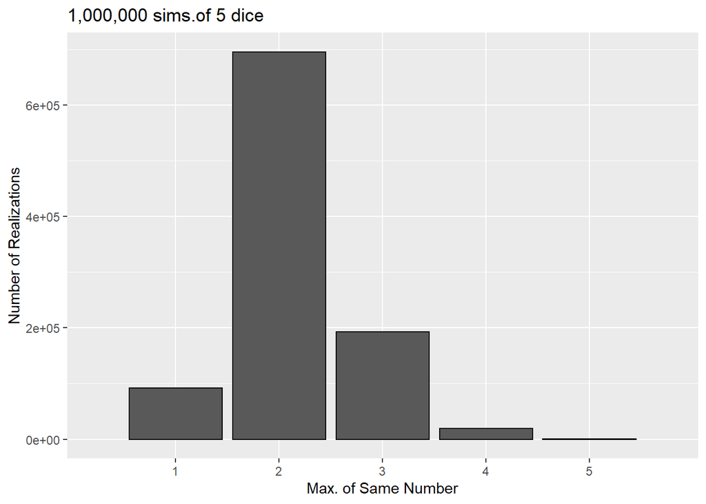

```r
# How many dice
numdice = 5
# How many simulations
numsims = 1000000
# Initializes a vector that contains the outcome of each simulation
maxnumber <- matrix(NA, nrow = numsims, ncol = 1)
rollsum <- matrix(NA, nrow = numsims, ncol = 1)

# Sets the seed
set.seed(12221979)

for (s in 1:numsims) {

  # Draws uniform r.v.
  uniform <- runif(n = numdice, min = 0, max = 1)
  # Initializes a vector
  dice <- matrix(-9, nrow = numdice, ncol = 1)
  # Transforms uniform r.v. into dice rolls
  # Applies inverse sampling
  dice[uniform >= 0 & uniform <= (1/6)] <- 1
  dice[uniform > (1/6) & uniform <= (2/6)] <- 2
  dice[uniform > (2/6) & uniform <= (3/6)] <- 3
  dice[uniform > (3/6) & uniform <= (4/6)] <- 4
  dice[uniform > (4/6) & uniform <= (5/6)] <- 5
  dice[uniform > (5/6) & uniform <= (6/6)] <- 6

  # Finds the mode of dice and stores in maxnum
  uniqv <- unique(dice)
  maxnum <- uniqv[which.max(tabulate(match(dice, uniqv)))]

  # Stores how many dice equal the mode
  maxnumber[s] <- sum(dice == maxnum)
  rollsum[s] <- sum(dice)
}

# Plots histogram of the max number from each simulation
maxnumberdf <- as.data.frame(maxnumber)
p <- ggplot(data=maxnumberdf, aes(x=V1)) +
  geom_bar( color="black") +
  scale_x_discrete(limits=c(1:numdice)) +
  labs(title="1,000,000 sims.of 5 dice",
       x="Max. of Same Number",
       y = "Number of Realizations")
p
```

```r
mean((rollsum == 15 | rollsum == 20) & maxnumber == 1)
```

```
## [1] 0.030573
```

# Question 3

## Part A

**Answer: {THTTTHTTHHTTHHTTHHHTTTHHH}**

I just randomly flipped a coin 25 times here. My longest streak of heads/tails were **three**

## Part B

For this question I set the:

- number of coins to be **25**
- number of trials to be **100000**
- probability of **50 %**

I then went in the code and replaced the areas where there was a **XXX** with the neccassary code.

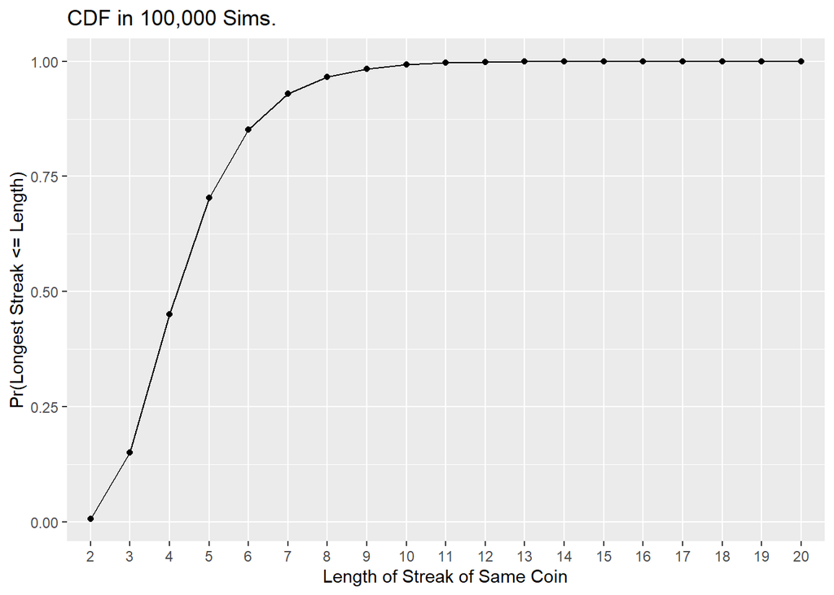

```r
# Sets the seed
set.seed(12221979)

# Defines the number of coins being flipped
numcoins = 25
# Defines the number of simulations
numsims = 100000
# Defines the probability that a coin is heads
probheads = 0.5

# Initializes a vector that contains the longest streak in every simulation
longstreak <- matrix(-9, nrow = numsims, ncol = 1)

# Uses a for loop to loop over simulations
for (s in 1:numsims) {

  # Uses rbinom() function to draw a series Bernoulli r.v.s
  # The number r.v.s in the series is defined by the parameter numcoins
  coins <- rbinom(numcoins, 1, probheads)
  # Initializes a vector that contains the streak after every coin
  streak <- matrix(-9, nrow = numcoins, ncol = 1)
  # Initilaizes the streak to 1 after the first coing
  streak[1] <- 1
  # Uses a for loop to calculate streak after every coin
  for (c in 2:numcoins) {

    streak[c] <- 1 + streak[c-1]*(coins[c] == coins[c-1])

  }

  # Identifies the longest streak and stores in longest streak vector
  longstreak[s] <- max(streak)

}

# Uses table command to create a pdf
pdf <- table(longstreak) / numsims
# Creates the cdf by looping over the pdf
cdf <- pdf
for (c in 2:dim(cdf)) {
  cdf[c] <- cdf[c-1] + pdf[c]
}

# Makes cdf into a data frame for plotting purposes
cdfdf <- as.data.frame(cdf)
# Plots the cdf
p <- ggplot(data=cdfdf, aes(x=longstreak, y=Freq, group=1)) +
  geom_line()+
  geom_point()+
  labs(title = "CDF in 100,000 Sims.", x = "Length of Streak of Same Coin", y = "Pr(Longest Streak <= Length)")
p
```

## Part C

**Answer: 0.29674**

To get this answer I subtracted **one (the total probability)** by the probability of getting a streak of **5 coins or less**. I did not include 5 in my probability calculation because the question stated : **what is the probability of having a streak of more than 5 coins show up?**

The question did not state what is the probability of having **5 and more coins show up** which implies that I only want the probability of 6 or more coins showing up.

```r
1 - cdfdf$Freq[cdfdf$longstreak == 5]
```

```
## [1] 0.29674
```

## Part D

**Answer: 0.8492**

My longest streak was **three** so I used the logic applied in **Q 3.C** to get the probability of having a longer streak than my current streak that I got.

```r
1 - cdfdf$Freq[cdfdf$longstreak == 3]
```

```
## [1] 0.8492
```